# Semana 7 - Ciencia de Datos con Python

## Índices de Calidad del Modelo

```python
indices = indices_general(MC,list(np.unique(y)))
```

```python
for k in indices:
    print("\n%s:\n%s"%(k,str(indices[k])))
```

```
##
## Matriz de Confusión:
## [[16  0  0]
##  [ 0 17  1]
##  [ 0  0 11]]
##
## Precisión Global:
## 0.9777777777777777
##
## Error Global:
## 0.022222222222222254
##
## Precisión por Categoría:
##    setosa  versicolor  virginica
## 0     1.0    0.944444        1.0
```

**Importancia de la variables**

```python
importancia = instancia_potenciacion.feature_importances_
print(importancia)
```

```
## [6.00513469e-04 1.71441716e-02 6.53319706e-01 3.28935609e-01]
```

## Graficando la importancia

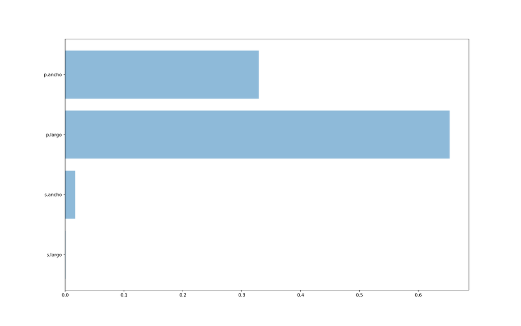

```python
etiquetas = X_train.columns.values
y_pos = np.arange(len(etiquetas))
plt.barh(y_pos, importancia, align='center', alpha=0.5)
plt.yticks(y_pos, etiquetas)
open_close_plot()
```

## Usando Selección de Variables a partir de la importancia de las variables

**Elimina la variable categórica, deja como variables predictoras en X solamente a p.largo y p.ancho**

```python
X = datos.iloc[:,2:4]
print(X.head())
```

```
##    p.largo  p.ancho
## 0      1.4      0.2
## 1      1.4      0.2
## 2      1.3      0.2
## 3      1.5      0.2
## 4      1.4      0.2
```

**Deja la variable a predecir en y**

```python
y = datos.iloc[:,4:5]
print(y.head())
```

```
##      tipo
## 0  setosa
## 1  setosa
## 2  setosa
## 3  setosa
## 4  setosa
```

**Mediante el constructor inicializa la instancia_potenciacion**

```python
instancia_potenciacion = GradientBoostingClassifier(n_estimators=10, random_state=0)
```

**Entrena el modelo llamando al método fit**

**Nota:**Esto se debe a que al ser Python orientado a Objetos,el modelo queda en un atributo de la instancia “instancia_potenciacion” llama el método fit de cla clase GradientBoostingClassifier.

```python
instancia_potenciacion.fit(X_train,y_train)
```

**Imprime las predicciones en testing**

```python
print("Las predicciones en Testing son: {}".format(instancia_potenciacion.predict(X_test)))
```

```
## Las predicciones en Testing son: ['virginica' 'versicolor' 'setosa' 'virginica' 'setosa' 'virginica'
##  'setosa' 'versicolor' 'versicolor' 'versicolor' 'virginica' 'versicolor'
##  'versicolor' 'versicolor' 'versicolor' 'setosa' 'versicolor' 'versicolor'
##  'setosa' 'setosa' 'virginica' 'versicolor' 'setosa' 'setosa' 'virginica'
##  'setosa' 'setosa' 'versicolor' 'versicolor' 'setosa' 'virginica'
##  'versicolor' 'setosa' 'virginica' 'virginica' 'versicolor' 'setosa'
##  'virginica' 'versicolor' 'versicolor' 'virginica' 'setosa' 'virginica'
##  'setosa' 'setosa']
```

**Porcentaje de predicción global**

```python
print("Precisión en Testing: {:.3f}".format(instancia_potenciacion.score(X_test, y_test)))
```

```
## Precisión en Testing: 0.978
```

**Matriz de confusión**

```python
prediccion = instancia_potenciacion.predict(X_test)
MC = confusion_matrix(y_test, prediccion)
print("Matriz de Confusión:\n{}".format(MC))
```

```
## Matriz de Confusión:
## [[16  0  0]
##  [ 0 17  1]
##  [ 0  0 11]]
```

## Índices de Calidad del Modelo

```python
indices = indices_general(MC,list(np.unique(y)))
```

```python
for k in indices:
    print("\n%s:\n%s"%(k,str(indices[k])))
```

```
##
## Matriz de Confusión:
## [[16  0  0]
##  [ 0 17  1]
##  [ 0  0 11]]
##
## Precisión Global:
## 0.9777777777777777
##
## Error Global:
## 0.022222222222222254
##
## Precisión por Categoría:
##    setosa  versicolor  virginica
## 0     1.0    0.944444        1.0
```

# Ejemplo Scoring de Crédito

```python
os.chdir("/Users/oldemarrodriguez/Google Drive/MDCurso/Datos")
print(os.getcwd())
```

```
## /Users/oldemarrodriguez/Google Drive/MDCurso/Datos
```

```python
datos = pd.read_csv('MuestraCredito5000.csv',delimiter=';',decimal=".")
print(datos.shape)
```

```
## (5000, 6)
```

```python
print(datos.head())
```

```
##    MontoCredito  IngresoNeto     ...       GradoAcademico  BuenPagador
## 0             1            1     ...                    1           Si
## 1             3            1     ...                    1           Si
## 2             2            1     ...                    1           Si
## 3             1            2     ...                    1           Si
## 4             1            1     ...                    1           Si
##
## [5 rows x 6 columns]
```

```python
print(datos.info())
```

```
## <class 'pandas.core.frame.DataFrame'>
## RangeIndex: 5000 entries, 0 to 4999
## Data columns (total 6 columns):
## MontoCredito         5000 non-null int64
## IngresoNeto          5000 non-null int64
## CoefCreditoAvaluo    5000 non-null int64
## MontoCuota           5000 non-null int64
## GradoAcademico       5000 non-null int64
## BuenPagador          5000 non-null object
## dtypes: int64(5), object(1)
## memory usage: 234.5+ KB
## None
```

**Nota:** Está tomando erroneamente los datos como numéricos, en este caso se deben convertir las variables ccategóricas porque en realidad estos numéros son códigos NO es que siempre se deban convertir las variables numéricas a categórica.

```python
datos['MontoCredito'] = datos['MontoCredito'].astype('category')
datos['IngresoNeto'] = datos['IngresoNeto'].astype('category')
datos['CoefCreditoAvaluo'] = datos['CoefCreditoAvaluo'].astype('category')
datos['MontoCuota'] = datos['MontoCuota'].astype('category')
datos['GradoAcademico'] = datos['GradoAcademico'].astype('category')
print(datos.head())
```

```
##   MontoCredito IngresoNeto     ...     GradoAcademico BuenPagador
## 0            1           1     ...                  1          Si
## 1            3           1     ...                  1          Si
## 2            2           1     ...                  1          Si
## 3            1           2     ...                  1          Si
## 4            1           1     ...                  1          Si
##
## [5 rows x 6 columns]
```

```python
print(datos.info())
```

```
## <class 'pandas.core.frame.DataFrame'>
## RangeIndex: 5000 entries, 0 to 4999
## Data columns (total 6 columns):
## MontoCredito         5000 non-null category
## IngresoNeto          5000 non-null category
## CoefCreditoAvaluo    5000 non-null category
## MontoCuota           5000 non-null category
## GradoAcademico       5000 non-null category
## BuenPagador          5000 non-null object
## dtypes: category(5), object(1)
## memory usage: 64.5+ KB
## None
```

**Elimina la variable catégorica, deja las variables predictoras en X**

```python
X = datos.iloc[:,:5]
print(X.head())
```

```
##   MontoCredito IngresoNeto      ...       MontoCuota GradoAcademico
## 0            1           1      ...                1              1
## 1            3           1      ...                1              1
## 2            2           1      ...                1              1
## 3            1           2      ...                1              1
## 4            1           1      ...                1              1
##
## [5 rows x 5 columns]
```

**Deja la variable a predecir en y**

```python
y = datos.iloc[:,5:6]
print(y.head())
```

```
##   BuenPagador
## 0          Si
## 1          Si
## 2          Si
## 3          Si
## 4          Si
```

**Con el 75% de los datos para entrenamiento**

```python
X_train, X_test, y_train, y_test = train_test_split(X, y, train_size=0.75, random_state=0)
```

**Mediante el constructor inicializa la instancia**

```python
instancia_potenciacion = GradientBoostingClassifier(n_estimators=100, random_state=0)
```

**Nota:**Observe que no hay variable que guarde el modelo como en R, esto se debe a que al ser Python orientado a Objetos, el modelo queda en un atributo de la instancia “instancia_potenciacion”

```python
instancia_potenciacion.fit(X_train,y_train)
```

**Imprime las predicciones en testing**

```python
print("Las predicciones en Testing son: {}".format(instancia_potenciacion.predict(X_test)))
```

```
## Las predicciones en Testing son: ['Si' 'Si' 'No' ... 'Si' 'Si' 'No']
```

**Porcentaje de predicción global**

```python
print("Precisión en Testing: {:.2f}".format(instancia_potenciacion.score(X_test, y_test)))
```

```
## Precisión en Testing: 0.96
```

**Matriz de confusión**

```python
prediccion = instancia_potenciacion.predict(X_test)
MC = confusion_matrix(y_test, prediccion)
print("Matriz de Confusión:\n{}".format(MC))
```

```
## Matriz de Confusión:
## [[ 120   46]
##  [  10 1074]]
```

## Índices de Calidad del Modelo

```python
indices = indices_general(MC,list(np.unique(y)))
```

```python
for k in indices:
    print("\n%s:\n%s"%(k,str(indices[k])))
```

```
##
## Matriz de Confusión:
## [[ 120   46]
##  [  10 1074]]
##
## Precisión Global:
## 0.9552
##
## Error Global:
## 0.04479999999999995
##
## Precisión por Categoría:
##          No        Si
## 0  0.722892  0.990775
```

**Importancia de la variables**

```python
importancia = instancia_potenciacion.feature_importances_
print(importancia)
```

```
## [0.11664359 0.03319699 0.36394907 0.17328435 0.312926  ]
```

## Graficando la importancia

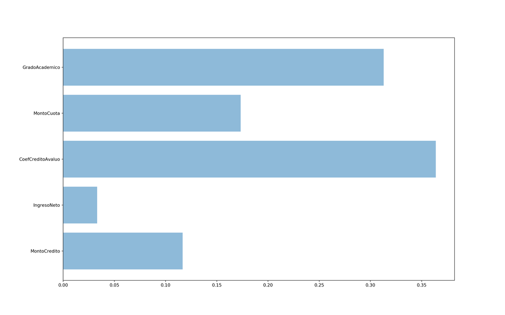

```python
etiquetas = X_train.columns.values
y_pos = np.arange(len(etiquetas))
plt.barh(y_pos, importancia, align='center', alpha=0.5)
plt.yticks(y_pos, etiquetas)
open_close_plot()
```